# GBI6 - BIOINFORMÁTICA

## **Pregunta 2 VISUALIZACION DE DATOS [5 PUNTOS]**

Para esta pregunta tiene que utilizar la data `df_long`.

### [1 PUNTO] 2.1 Cree la funcion `tcga_boxplots` para visualizar boxplots y jitterplots. El único parámetro de la función es `dataset`. La función debe crear un boxplot de los niveles de expresión para cada gen.

```r
# Escriba el código para crear la función tcga_boxplots
  ##visualizar boxplots
library(ggplot2)
long_df <- long_df[order(long_df$dataset),]
colnames(long_df)
```

```
## [1] "bcr_patient_barcode" "dataset"             "gen"
## [4] "expresion_level"
```

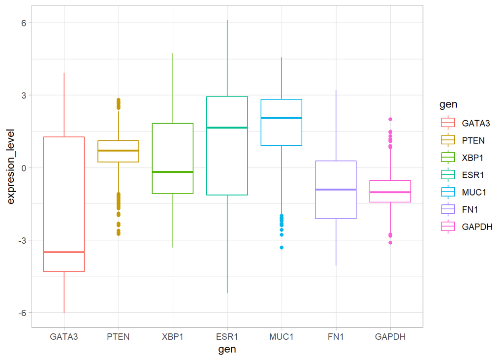

```r
df_long <- long_df[,-1]

tcga_boxplots = ggplot(df_long, aes(x= gen, y = expresion_level)) + geom_boxplot(aes(color = gen)) + theme_light()
tcga_boxplots
```

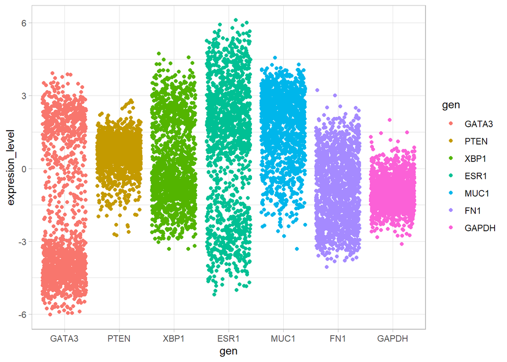

```r
    ##visualizar jitter
ggplot(df_long, aes(x= gen, y = expresion_level)) + geom_jitter(aes(color = gen)) + theme_light()
```

### [0.5 PUNTOS] 2.2 Utilizando la función `lapply()` genera la lista `cancertype_boxplots` con las gráficas para cada tipo de cancer (cada tipo de dataset).

```r
# Escriba el código para generar la lista
library(ggplot2)
long_df <- long_df[order(long_df$dataset),]
colnames(long_df)
```

```
## [1] "bcr_patient_barcode" "dataset"             "gen"
## [4] "expresion_level"
```

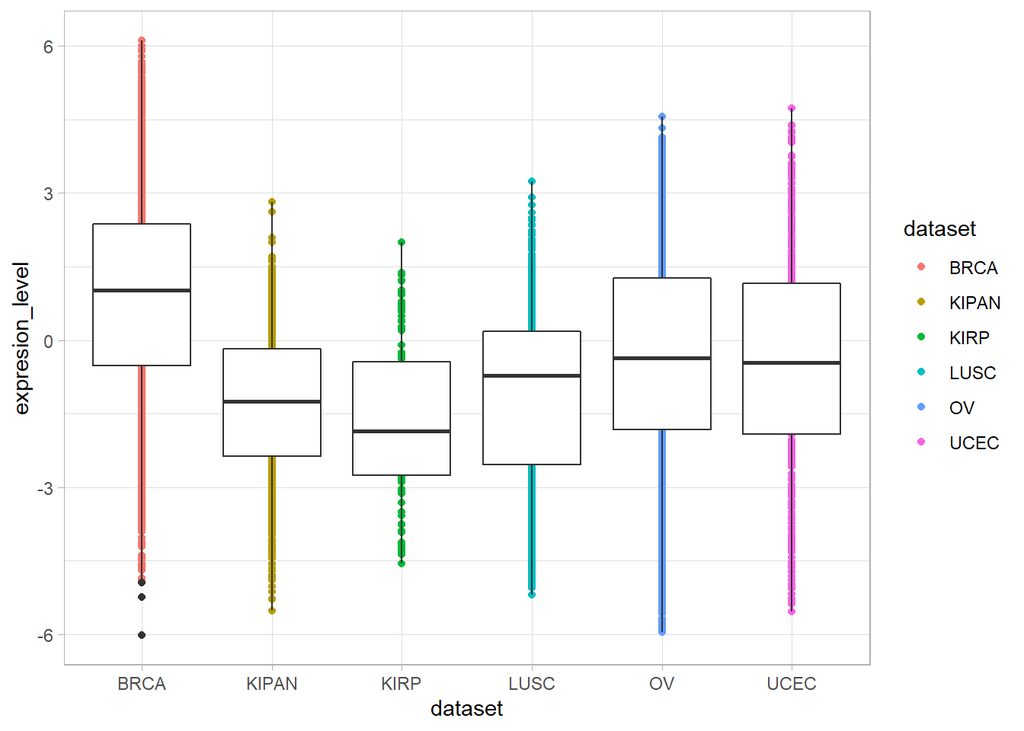

```r
df_long <- long_df[,-1]
cancertype_boxplots = ggplot(df_long, aes(x = dataset, y = expresion_level )) + geom_point(aes(color= dataset)) + geom_boxplot() + theme_light()
cancertype_boxplots
```

### [0.5 PUNTOS] 2.3 Guarde en el subdirectorio `result` el tercer plot de la lista `cancertype_boxplots` con el nombre `boxplot3.png`. La definición de a figura debe ser de 300dpi.

[figure not shown]

```r
# Escriba el código para guardar la tercera figura de la lista.

boxplot3.png = ggplot(df_long, aes(x= "KIRP" , y = expresion_level)) + geom_boxplot(aes(color = "KIRP")) + theme_light()
boxplot3.png
```